# Part 1: Introduction to R Programming

B. Efficient R Programming

Mingyang Lu

10/12/2021

So far, the basics of R are introduced. Writing R code is not difficult, in fact quite intuitive. However, using R efficiently is not easy. R scripts are interpretive, thus R can’t compete with compiled languages, such as C and Fortran, in terms of computational efficiency. That becomes especially important for numerical analyses. Interestingly, many approaches we learn from compiled languages are not necessarily applicable to R programming. Here, I will introduce a few techniques to make R codes more efficient. I highly recommend the online book [Efficient R programming](https://csgillespie.github.io/efficientR/) for details of this topic. For example, one should use factors when possible, as they are good for statistical analysis. A general principle is to avoid computation in R scripts. A good practice of R programming is to avoid intensive/iterative calculations directly in R code. The goal is to do these calculations with more efficient functions, typically written in C or Fortran.

# Avoid growing vectors

The following code is extremely slow for large n.

```r
n = 10 # Set the value of n to 10
v = c() # Create an empty vector v
for (i in seq_len(n)) { # Use a for loop to iterate from 1 to n
  v = c(v, i^2) # Append the square of i to vector v
}
v # Print the resulting vector v
```

```
##  [1]   1   4   9  16  25  36  49  64  81 100
```

A better way creates an array of final length first.

```r
n = 10
v = numeric(n) # Create a numeric vector v of length n filled with zeros
for (i in seq_len(n)) {
  v[i] = i^2 # Assign the square of i to the corresponding element in the vector v
}
v
```

```
##  [1]   1   4   9  16  25  36  49  64  81 100
```

# Vectorize codes

An even better approach is the following. It uses vector operations instead.

```r
n = 10
v = seq_len(n) # Generate a sequence from 1 to n
v = v * v # Square each element in the vector v
v
```

```
##  [1]   1   4   9  16  25  36  49  64  81 100
```

Iteration is commonly used in programming. Unfortunately, iteration, *e.g.*, using a For Loop, is very slow in R. For example, the following code calculates the mean and standard deviation (SD) of a series of numbers. Please note that the definition of SD here is the mathematical definition.

$$\sigma(\mathbf{x})=\sqrt{\frac{\sum_{j=1}^{n}(\mathbf{x_j}-\mathbf{\overline{x}})^2}{n}}$$
It can be shown that the following formula is equivalent and more efficient to be coded.

$$\sigma(\mathbf{x})=\sqrt{\frac{\sum_{j=1}^{n}\mathbf{x_j}^2}{n}
- \left(\frac{\sum_{j=1}^{n}\mathbf{x_j}}{n}\right)^2}$$

```r
# Initialize variables
my_sum = 0
my_sum2 = 0
num = 100

for (i in seq_len(num)) { # Loop through a sequence from 1 to num
  my_sum = my_sum + i
  my_sum2 = my_sum2 + i^2
}

# Calculate mean and standard deviation
my_mean = my_sum / num
my_sd = sqrt(my_sum2 / num - my_mean^2)

# Print the mean and standard deviation
my_mean
```

```
## [1] 50.5
```

```r
my_sd
```

```
## [1] 28.86607
```

While the above code is typical for C or Fortran, a better approach for R is to use vector operations.

```r
num = 100 # Define num
v = seq_len(num) # Create a sequence from 1 to num

# Calculate mean, mean square, and standard deviation
my_mean = mean(v)
my_mean_square = mean(v^2)
my_sd = sqrt(my_mean_square - my_mean^2)

# Print the mean and standard deviation
my_mean
```

```
## [1] 50.5
```

```r
my_sd
```

```
## [1] 28.86607
```

Apply can be used to perform operations for columns (or rows) of a matrix.

```r
library(MASS) # Load the necessary library for matrix operations

mat = matrix(rnorm(16), nrow = 4) # Generate a random matrix of size 4x4

# Calculate means, means square, and standard deviations
means = apply(mat, 2, mean)
my_mean_square = apply(mat * mat, 2, mean)
sd = sqrt(my_mean_square - means^2)

sd # Print the standard deviations
```

```
## [1] 0.6588735 1.0592286 0.9403377 1.2060033
```

In statistics, a lightly different definition is typically used.

$$\sigma(\mathbf{x})=\sqrt{\frac{\sum_{j=1}^{n}(\mathbf{x_j}-\mathbf{\overline{x}})^2}{n-1}}$$
For example, the sd function in R uses this definition.

```r
apply(mat, 2, sd)
```

```
## [1] 0.7608016 1.2230918 1.0858084 1.3925726
```

# Byte compile package

Any function can be compiled into byte code for an easy performance boost.

```r
library(compiler)
my_sd =  function(x) {   # define the function
  my_mean = mean(x)
  my_mean2 = mean(x*x)
  return(sqrt(my_mean2 - my_mean**2))
}
cmp_sd = cmpfun(my_sd)   # compile it to byte code
cmp_sd(seq_len(100))   # same calculations as a previous example, but with compiled function
```

```
## [1] 28.86607
```

```r
apply(mat, 2, cmp_sd)  # apply to a matrix
```

```
## [1] 0.6588735 1.0592286 0.9403377 1.2060033
```

# Use C/Fortran codes

Many R packages are written in a compiled language. It is important to use them when possible. It is also feasible to write functions in C, C++, or Fortran, and call these functions from R. Here is an example of Fortran subroutines, provided in the file “extra/src/sub_cal_sd.f90”. Note that only integer, double precision and logical arguments are allowed in the Fortran-R interface approach.

```
subroutine cal_sd(n,x,sd)
  implicit none
  integer,intent(in) :: n
  double precision, intent(in) :: x(n)
  double precision, intent(out) :: sd
  integer :: i
  double precision :: mean, mean2
  mean = 0.d0
  mean2 = 0.d0
  do i = 1, n
    mean = mean + x(i)
    mean2 = mean2 + x(i)**2
  end do
  mean = mean/n
  mean2 = mean2/n
  sd = sqrt(mean2 - mean**2)
end subroutine cal_sd
```

The Fortran code needs to be first compiled into a .so file. This needs to be done in command line with a Fortran compiler (gfortran from gcc).

```
gfortran -fpic -shared extra/src/sub_cal_sd.f90 -o extra/src/sub_cal_sd.so
```

Then, in R load the shared library

```r
dyn.load("extra/src/sub_cal_sd.so")
```

cal_sd can be called in R below. The arguments of the Fortran subroutines can be found in the output list.

```r
n = 100
v = seq_len(n)
my_sd = 0.0
results = .Fortran("cal_sd",as.integer(n),as.double(v), my_sd)
results             # [[3]] outputs the sd
```

```
## [[1]]
## [1] 100
##
## [[2]]
##   [1]   1   2   3   4   5   6   7   8   9  10  11  12  13  14  15  16  17  18
##  [19]  19  20  21  22  23  24  25  26  27  28  29  30  31  32  33  34  35  36
##  [37]  37  38  39  40  41  42  43  44  45  46  47  48  49  50  51  52  53  54
##  [55]  55  56  57  58  59  60  61  62  63  64  65  66  67  68  69  70  71  72
##  [73]  73  74  75  76  77  78  79  80  81  82  83  84  85  86  87  88  89  90
##  [91]  91  92  93  94  95  96  97  98  99 100
##
## [[3]]
## [1] 28.86607
```

To make it even more convenient, one can write an R wrapper.

```r
 my_sd_R <- function(x) {
   if (!is.numeric(x))
           stop("argument x must be numeric")
   my_sd = 0.0
   results =  .Fortran("cal_sd", as.integer(length(x)), as.double(x), my_sd)
   return(results[[3]])
 }
my_sd_R(seq_len(100))
```

```
## [1] 28.86607
```

More details can be found in [this page](http://users.stat.umn.edu/~geyer/rc/).

# Parallelization

Lastly, parallelization is another way to improve the performance of R. If simple parallelization is needed, we can use Apply functions. Simply setup the desired calculations in a list. Instead of using lapply, use mclapply and specify the number of cores in use. As demonstrated below, the code with parallelization is much faster.

```r
library(parallel)   # load the parallel library
library(microbenchmark)  # use microbenchmark library for timing
numCores = detectCores()     # the number of available cores
numCores
```

```
## [1] 14
```

```r
tests = seq(1, 10000)
my_test <- function(test_id) {
  v = rnorm(1000)
  return(my_sd_R(v))
}
my_benchmark = microbenchmark(results_noparallel = lapply(tests, my_test),
               results_withparallel = mclapply(tests, my_test, mc.cores = numCores),
               times = 10, unit = "s")
```

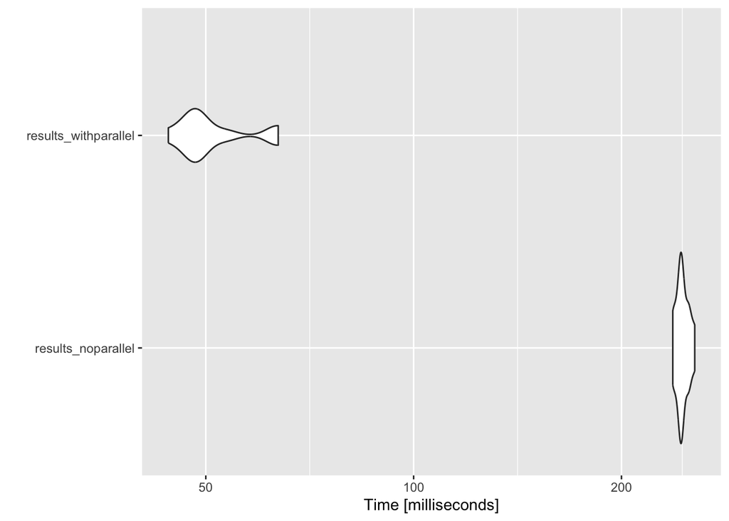

```r
microbenchmark:::autoplot.microbenchmark(my_benchmark)
```

For additional read, please [check this page](https://nceas.github.io/oss-lessons/parallel-computing-in-r/parallel-computing-in-r.html)